# Week 10: Effects of Spatial Dependence

# Areal Data and Spatial Autocorrelation

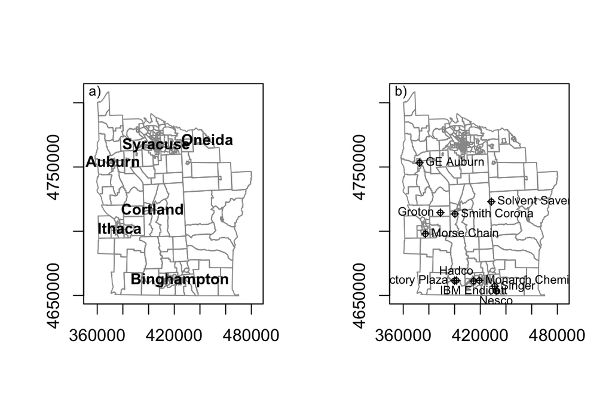

```r
NY8 <- readOGR("Data", "NY8_utm18")
TCE <- readOGR("Data", "TCE")
cities <- readOGR("Data", "NY8cities")

par(mfrow=c(1,2))
plot(NY8, border="grey60", axes=TRUE)
text(coordinates(cities), labels=as.character(cities$names), font=2, cex=0.9)
text(bbox(NY8)[1,1], bbox(NY8)[2,2], labels="a)", cex=0.8)

plot(NY8, border="grey60", axes=TRUE)
points(TCE, pch=1, cex=0.7)
points(TCE, pch=3, cex=0.7)
text(coordinates(TCE), labels=as.character(TCE$name), cex=0.7,
 font=1, pos=c(4,1,4,1,4,4,4,2,3,4,2), offset=0.3)
text(bbox(NY8)[1,1], bbox(NY8)[2,2], labels="b)", cex=0.8)
```

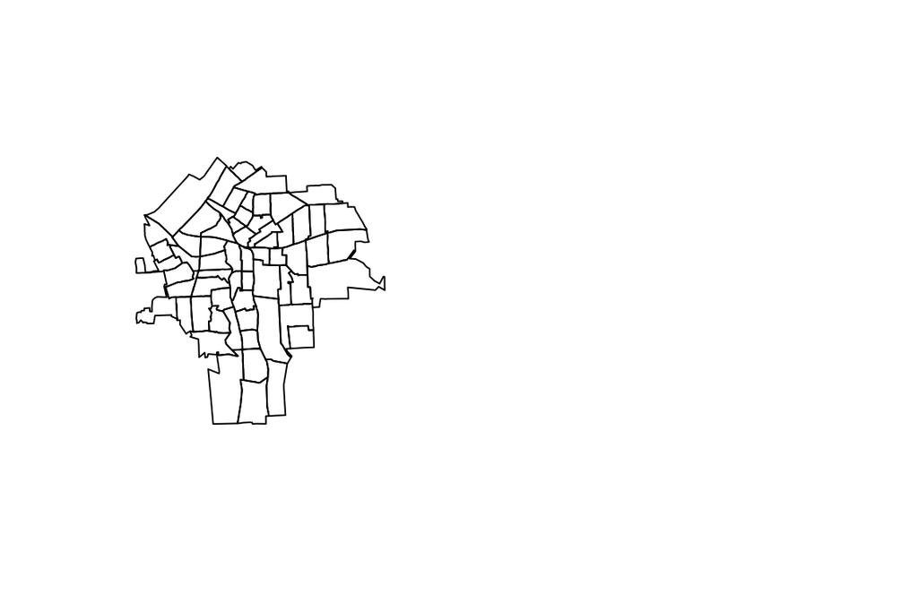

```r
# Syracuse

Syracuse <- NY8[NY8$AREANAME == "Syracuse city",]
plot(Syracuse)

# creating conginuity neighours

Sy0_nb=poly2nb(Syracuse, queen=T)
Sy1_nb=poly2nb(Syracuse, queen=F)

# creating distance-based neighours

coords <- coordinates(Syracuse)
IDs <- row.names(Syracuse)
Sy8_nb <- knn2nb(knearneigh(coords, k=1), row.names=IDs)
Sy9_nb <- knn2nb(knearneigh(coords, k=2), row.names=IDs)
Sy10_nb <- knn2nb(knearneigh(coords, k=4), row.names=IDs)
dsts <- unlist(nbdists(Sy8_nb, coords))
Sy11_nb <- dnearneigh(coords, d1=0, d2=0.75*max(dsts), row.names=IDs)


# Spatial weights

# Weights have different style, e.g., 'W' row-standarized weights, 'B' binary

Sy0_lw_W <- nb2listw(Sy0_nb)
Sy0_lw_W
names(Sy0_lw_W)


1/rev(range(card(Sy0_lw_W$neighbours)))
summary(unlist(Sy0_lw_W$weights))
summary(sapply(Sy0_lw_W$weights, sum))


Sy0_lw_B <- nb2listw(Sy0_nb, style="B")
summary(unlist(Sy0_lw_B$weights))
summary(sapply(Sy0_lw_B$weights, sum))

# define weight based on distance

dsts <- nbdists(Sy0_nb, coordinates(Syracuse))
idw <- lapply(dsts, function(x) 1/(x/1000))
Sy0_lw_idwB <- nb2listw(Sy0_nb, glist=idw, style="B")
summary(unlist(Sy0_lw_idwB$weights))
summary(sapply(Sy0_lw_idwB$weights, sum))

# Allow all-zeros neighourhood, the folling line will output errors,
# but with zero.polic=T, the error will be gone.

try(Sy0_lw_D1 <- nb2listw(Sy11_nb, style="B"))

Sy0_lw_D1 <- nb2listw(Sy11_nb, style="B", zero.policy=TRUE)
print(Sy0_lw_D1, zero.policy=TRUE)

# Importing the specificition of spatial neighbours and weights generated by GeoDa

NY_nb <- read.gal("Data/NY_nb.gal", region.id=row.names(NY8))

# Using Weights to Simulate Spatial Autocorrelation

set.seed(987654)
n <- length(Sy0_nb)
uncorr_x <- rnorm(n)
rho <- 0.5
# (I-\rho*w)
autocorr_x <- invIrW(Sy0_lw_W, rho) %*% uncorr_x


oopar <- par(mfrow=c(1,2), mar=c(4,4,3,2)+0.1)
```

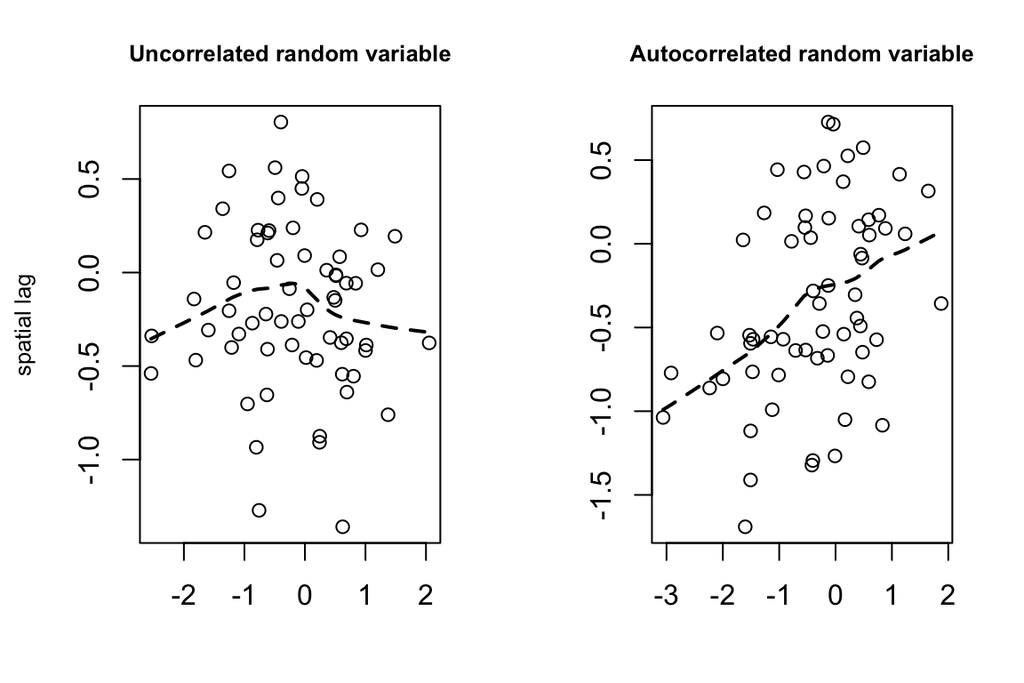

```r
plot(uncorr_x, lag(Sy0_lw_W, uncorr_x), xlab="", cex.lab=0.8,
 ylab="spatial lag", main="Uncorrelated random variable", cex.main=0.8)
lines(lowess(uncorr_x, lag(Sy0_lw_W, uncorr_x)), lty=2, lwd=2)
plot(autocorr_x, lag(Sy0_lw_W, autocorr_x),
 xlab="", ylab="",
 main="Autocorrelated random variable", cex.main=0.8, cex.lab=0.8)
lines(lowess(autocorr_x, lag(Sy0_lw_W, autocorr_x)), lty=2, lwd=2)
```

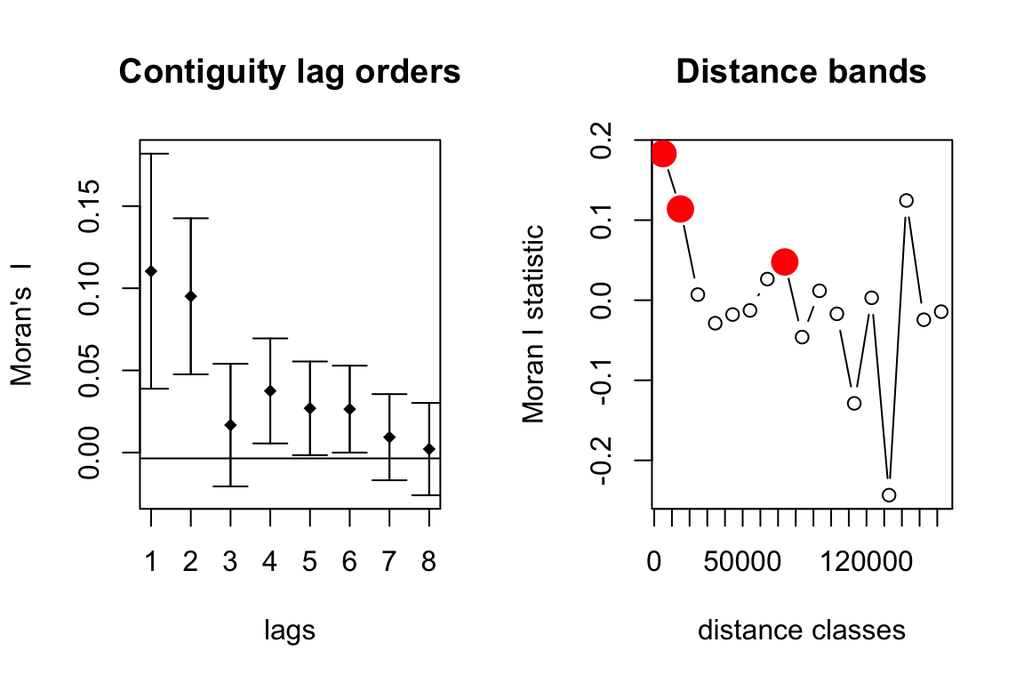

```r
par(oopar)

# Spatial Autocorrelation: Tests

moran.test(uncorr_x, listw=Sy0_lw_W)
moran.test(autocorr_x, listw=Sy0_lw_W)
moran.test(autocorr_x, listw=nb2listw(Sy9_nb, style="W"))

## effect of trend or assumption of mean

et <- coords[,1] - min(coords[,1])
trend_x <- uncorr_x + 0.00025 * et
moran.test(trend_x, listw=Sy0_lw_W)
lm.morantest(lm(trend_x ~ et), listw=Sy0_lw_W)


# Change of Moran's I with order of spatial contiguity and distances

NY_nb <- read.gal("Data/NY_nb.gal", region.id=row.names(NY8))
#K <- moran(NY8$Cases, listw=nb2listw(NY_nb, style="B"), n=length(NY8$Cases), S0=Szero(nb2listw(NY_nb, style="B")))$K

cor8 <- sp.correlogram(neighbours=NY_nb, var=NY8$Cases, order=8, method="I", style="C")

library(pgirmess)
corD <- correlog(coordinates(NY8), NY8$Cases, method="Moran")

oopar <- par(mfrow=c(1,2))
plot(cor8, main="Contiguity lag orders")
plot(corD, main="Distance bands")
```

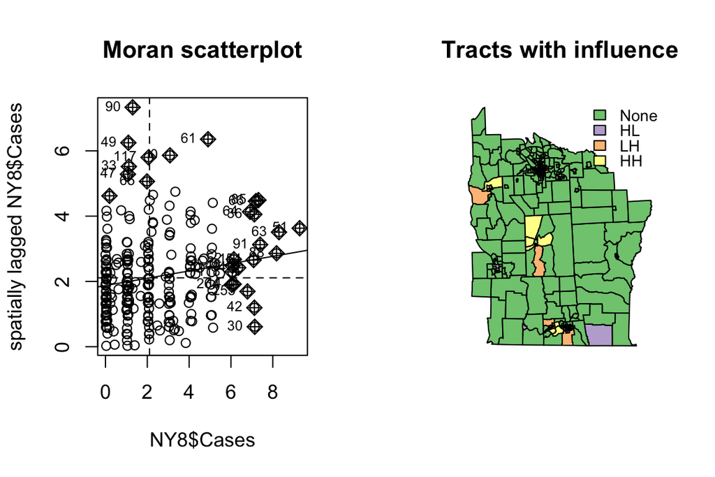

```r
par(oopar)

# Moran's I plot

library(RColorBrewer)
oopar <- par(mfrow=c(1,2))
msp <- moran.plot(NY8$Cases, listw=nb2listw(NY_nb, style="C"), quiet=TRUE)
title("Moran scatterplot")
infl <- apply(msp$is.inf, 1, any)
x <- NY8$Cases
lhx <- cut(x, breaks=c(min(x), mean(x), max(x)), labels=c("L", "H"), include.lowest=TRUE)
wx <- lag(nb2listw(NY_nb, style="C"), NY8$Cases)
lhwx <- cut(wx, breaks=c(min(wx), mean(wx), max(wx)), labels=c("L", "H"), include.lowest=TRUE)
lhlh <- interaction(lhx, lhwx, infl, drop=TRUE)
cols <- rep(1, length(lhlh))
cols[lhlh == "H.L.TRUE"] <- 2
cols[lhlh == "L.H.TRUE"] <- 3
cols[lhlh == "H.H.TRUE"] <- 4
plot(NY8, col=brewer.pal(4, "Accent")[cols])
legend("topright", legend=c("None", "HL", "LH", "HH"), fill=brewer.pal(4, "Accent"), bty="n", cex=0.8, y.intersp=0.8)
title("Tracts with influence")
```

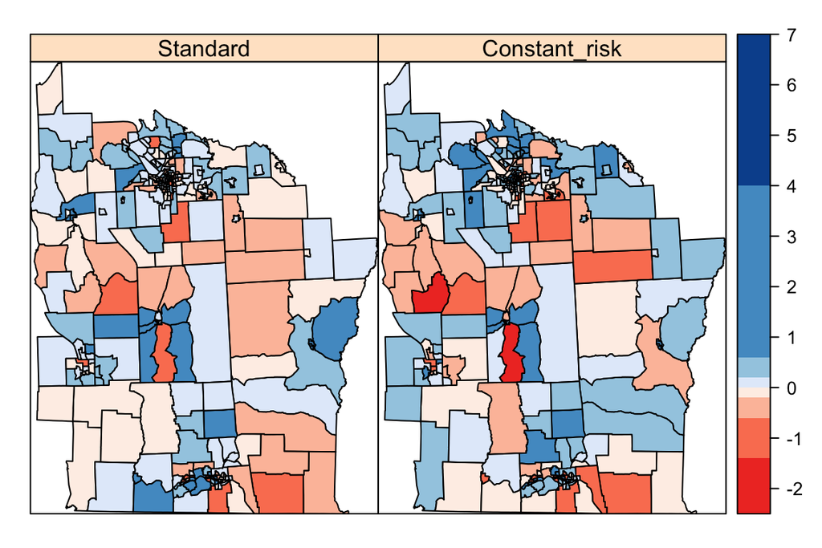

```r
par(oopar)

# Local test
lm1 <- localmoran(NY8$Cases, listw=nb2listw(NY_nb, style="C"))
#lm2 <- as.data.frame(localmoran.sad(lm(Cases ~ 1, NY8), nb=NY_nb, style="C"))
#lm3 <- as.data.frame(localmoran.exact(lm(Cases ~ 1, NY8), nb=NY_nb, style="C"))

# Local test for rate
r <- sum(NY8$Cases)/sum(NY8$POP8)
rni <- r*NY8$POP8
lw <- nb2listw(NY_nb, style="C")
sdCR <- (NY8$Cases - rni)/sqrt(rni)
wsdCR <- lag(lw, sdCR)
I_CR <- sdCR * wsdCR

gry <- c(rev(brewer.pal(8, "Reds")[1:6]), brewer.pal(6, "Blues"))
NY8$Standard <- lm1[,1]
NY8$"Constant_risk" <- I_CR
#nms <- match(c("Standard", "Constant_risk"), names(NY8))
spplot(NY8, c("Standard", "Constant_risk"), at=c(-2.5,-1.4,-0.6,-0.2,0,0.2,0.6,4,7), col.regions=colorRampPalette(gry)(8))
```

# Modeling areal data

## Spatial statistical approach

### Simultaneous autoregressive model (SAR)

The SAR specification uses a regression on the values from the other areas to account for the spatial dependence. This means that the error terms $e$ are modelled so that they depend on each other in the following way:

$$e_i=\sum_{i=1}^{m} b_{ij}e_i+\epsilon_i$$

where $\epsilon_i \sim N(0, \sigma_i^2)$

or
$$e_1, e_2, \ldots, e_n \sim N(0, (I-B)^{-1}D((I-B)^{-1})^T)$$

If denote $e_i=Y-X^T\beta$, then the SAR model could be expressed as:

$Y-X^T\beta = B(Y-X^T\beta)+\epsilon$ or $(I-B)(Y-X^T\beta)=\epsilon$

where $B$ is a matrix that contains the dependence parameters $b_{ij}$ and $I$ is the identity matrix of the required dimension. It is important to point out that in order for this SAR model to be well defined, the matrix $I − B$ must be non-singular.

A common practice to specify $B$ is $B=\rho W$, where $W$ is the spatial weight matrix and $\rho$ is the `spatial autoregression parameter`.

Frequently employed in the spatial econometric literature with two variants, spatial lag model and spatial error model.

### Conditional autoregressive model (CAR)

The CAR specification relies on the conditional distribution of the spatial error terms. In this case, the distribution of $e_i$ conditioning on $e_{−i}$ is given.

$$e_i|e_{-i} \sim N(\sum_{j}b_{ij}e_j, \tau_i^2)$$

where $j$ is the neighbors of $i$.

Using Brook’s Lemma we can obtain:

$$e_1, e_2, \ldots, e_n \sim N(0, (I-B)^{-1}D)$$

Compared to SAR model, the CAR model is easier to be fitted into a Bayesian hierarchical models.

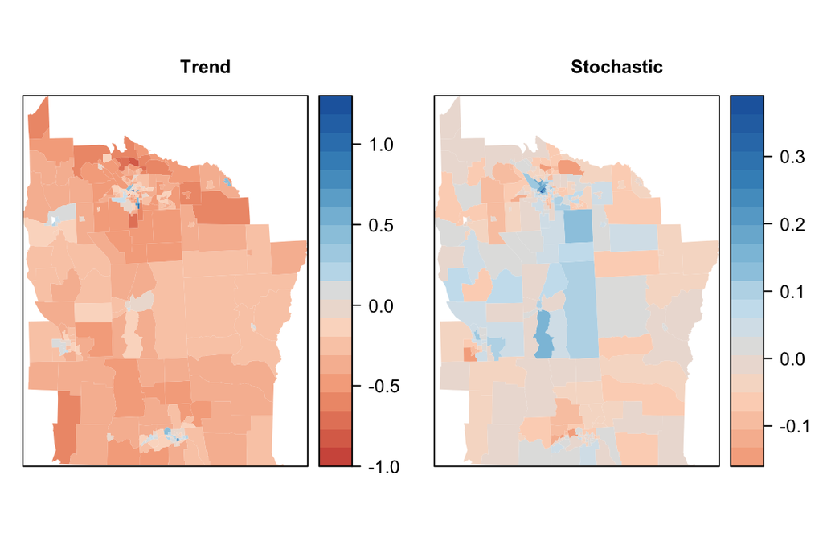

```r
nylm <- lm(Z~PEXPOSURE+PCTAGE65P+PCTOWNHOME, data=NY8)
summary(nylm)
NY8$lmresid <- residuals(nylm)
NYlistw<-nb2listw(NY_nb, style = "B")
lm.morantest(nylm, NYlistw)


# Spatial conditional and simultaneous autoregression

nysar<-spautolm(Z~PEXPOSURE+PCTAGE65P+PCTOWNHOME, data=NY8, listw=NYlistw)
summary(nysar)

nylam1 <- c(nysar$lambda)
nylam2 <- c(LR1.spautolm(nysar)$p.value)

# Display
NY8$sar_trend <- nysar$fit$signal_trend
NY8$sar_stochastic <- nysar$fit$signal_stochastic
rds <- colorRampPalette(brewer.pal(8, "RdBu"))
tr_at <- seq(-1, 1.3, length.out=21)
tr_rds <- rds(sum(tr_at >= 0)*2)[-(1:(sum(tr_at >= 0)-sum(tr_at < 0)))]
tr_pl <- spplot(NY8, c("sar_trend"), at=tr_at, col="transparent", col.regions=tr_rds, main=list(label="Trend", cex=0.8))
st_at <- seq(-0.16, 0.39, length.out=21)
st_rds <- rds(sum(st_at >= 0)*2)[-(1:(sum(st_at >= 0)-sum(st_at < 0)))]
st_pl <- spplot(NY8, c("sar_stochastic"), at=st_at, col="transparent", col.regions=st_rds, main=list(label="Stochastic", cex=0.8))
plot(tr_pl, split=c(1,1,2,1), more=TRUE)
plot(st_pl, split=c(2,1,2,1), more=FALSE)
```

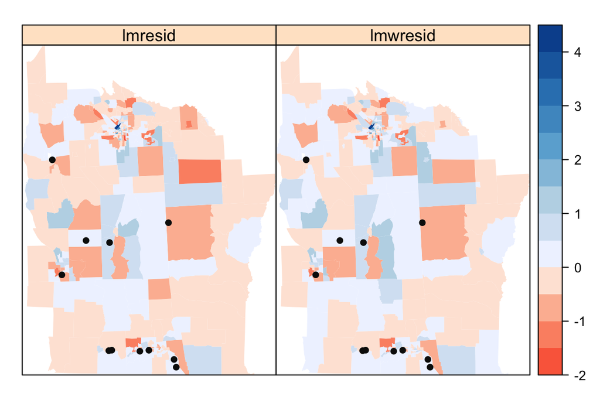

```r
# The proximity to a TCE seems not to be significant, after we include
# the population as weights, it becomes significant.

nylmw <- lm(Z~PEXPOSURE+PCTAGE65P+PCTOWNHOME, data=NY8, weights=POP8)
summary(nylmw)
NY8$lmwresid <- residuals(nylmw)

# Display
gry <- c(rev(brewer.pal(6, "Reds")[1:4]), colorRampPalette(brewer.pal(5, "Blues"))(9))
TCEpts <- list("sp.points", TCE, pch=16, col="grey5")
spplot(NY8, c("lmresid", "lmwresid"), sp.layout=list(TCEpts), col.regions=gry, col="transparent", lwd=0.5, at=seq(-2,4.5,0.5))
```

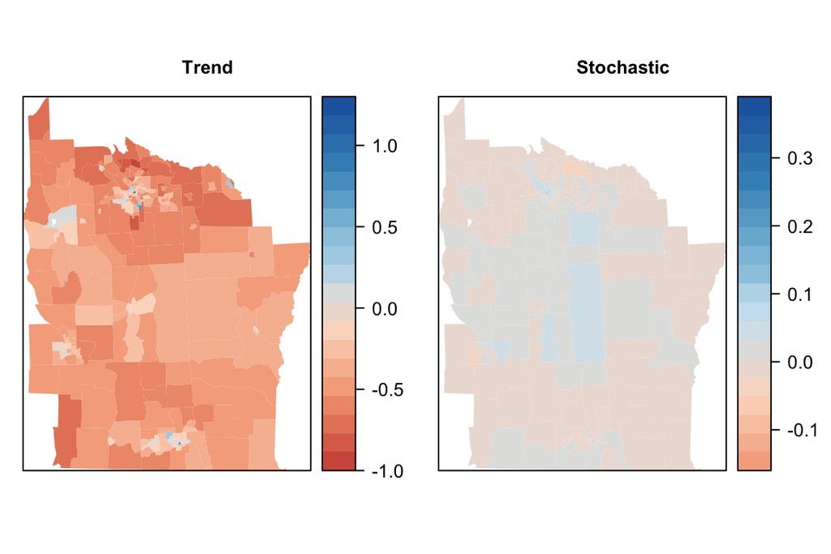

```r
# Now check the moran's again

lm.morantest(nylmw, NYlistw)

# Include weights in spautolm

nysarw<-spautolm(Z~PEXPOSURE+PCTAGE65P+PCTOWNHOME , data=NY8, listw=NYlistw, weights=POP8)
summary(nysarw)

NY8$sarw_trend <- nysarw$fit$signal_trend
NY8$sarw_stochastic <- nysarw$fit$signal_stochastic
tr_pl <- spplot(NY8, c("sarw_trend"), at=tr_at, col="transparent", col.regions=tr_rds, main=list(label="Trend", cex=0.8))
st_pl <- spplot(NY8, c("sarw_stochastic"), at=st_at, col="transparent", col.regions=st_rds, main=list(label="Stochastic", cex=0.8))
plot(tr_pl, split=c(1,1,2,1), more=TRUE)
plot(st_pl, split=c(2,1,2,1), more=FALSE)
```

```r
# Conditional Autoregressive Models

nycar<-spautolm(Z~PEXPOSURE+PCTAGE65P+PCTOWNHOME , data=NY8, family="CAR",
   listw=NYlistw)
summary(nycar)


nylam1 <- c(nycar$lambda)


nycarw<-spautolm(Z~PEXPOSURE+PCTAGE65P+PCTOWNHOME, data=NY8, family="CAR",
   listw=NYlistw, weights=POP8)
summary(nycarw)


nysarwM<-spautolm(Z~PEXPOSURE+PCTAGE65P+PCTOWNHOME, data=NY8, family="SAR",
   listw=NYlistw, weights=POP8, method="Matrix")


summary(nysarwM)


# SMA model
#nysmaw<-spautolm(Z~PEXPOSURE+PCTAGE65P+PCTOWNHOME, data=NY8, family="SMA",
#   listw=NYlistw, weights=POP8)
#summary(nysmaw)

# Spatial economitrics approach

#NYlistwW <- nb2listw(NY_nb, style = "W")
#res <- lm.LMtests(nylm, listw=NYlistwW, test="all")
#tres <- t(sapply(res, function(x) c(x$statistic, x$parameter, x$p.value)))
#colnames(tres) <- c("Statistic", "df", "p-value")
#printCoefmat(tres)
#
#
#nylag <- lagsarlm(Z~PEXPOSURE+PCTAGE65P+PCTOWNHOME, data=NY8, listw=NYlistwW)
#summary(nylag)
#bptest.sarlm(nylag)
#
#
#
#McRes <- sarml(Z~PEXPOSURE+PCTAGE65P+PCTOWNHOME, wmat=listw2mat(NYlistwW), eigvar=eigenw(NYlistwW), print=FALSE, data=NY8)
#c(McRes$beta, rho=McRes$rho, sig2=McRes$sig2)
#
#
#nymix <- lagsarlm(Z~PEXPOSURE+PCTAGE65P+PCTOWNHOME, data=NY8, listw=NYlistwW, type="mixed")
#nymix
#anova(nymix, nylag)
#
#
#W <- as(as_dgRMatrix_listw(NYlistwW), "CsparseMatrix")
#trMat <- trW(W, type="mult")
#head(trMat)
#
#
#
#
#nyerr <- errorsarlm(Z~PEXPOSURE+PCTAGE65P+PCTOWNHOME, data=NY8, listw=NYlistwW)
#summary(nyerr)
#LR.sarlm(nyerr, nymix)
#
#
#nyerr1 <- errorsarlm(Z~PEXPOSURE+PCTAGE65P+PCTOWNHOME, data=NY8, listw=NYlistwW, etype="emixed")
#coef(nyerr1)
#
```